## Practical Machine Learning - Course Project

### Background

Human Activity Recognition (HAR) has become very active research area. One approach to recognizing activity is analyzing information from wearable sensors. This project explores the possibility to apply machine learning methods to classify the data collected from wearable sensors. The aim is to build machine learning model that would help predict with reasonable accuracy whether a weight lifting exercise is performed in one of several manners.

This work is based on the data available from http://groupware.les.inf.puc-rio.br/har.

Reference:

*Velloso, E.; Bulling, A.; Gellersen, H.; Ugulino, W.; Fuks, H. Qualitative Activity Recognition of Weight Lifting Exercises. Proceedings of 4th International Conference in Cooperation with SIGCHI (Augmented Human ’13) . Stuttgart, Germany: ACM SIGCHI, 2013.*

Web link: http://groupware.les.inf.puc-rio.br/har#ixzz3oxAZvgwL

### Study design

- Get the data
- Partition the given training set into three sub-sets:
  - training set
  - validation set
  - testing set
- Build several models using the training set.
- Use the validation set to compare the models and select one of them as final.
- Evaluate the selected model on the test set.

Note that the testing set as result of the partitioning is only used for out of sample error evaluation. Also this is not to be confused with the “given test set”, which is used to submit the predicted values to Coursera for grading.

Once the selected method is evaluated, it will be used to make predictions on the given test set and submit the results.

### Libraries and global settings

The following libraries will be used.

```r
# Load the needed libraries
library(dplyr)
library(ggplot2)
library(caret)
library(corrplot )
library(gridExtra)

# Clear the workspace
rm(list=ls())
```

The following logical variable is used to specify if the model is built and saved already. Once built, the model is saved and later loaded from file to save time for the rest of the work.

```r
model.saved = TRUE
```

### Data

The original data are available from

- http://groupware.les.inf.puc-rio.br/har#weight_lifting_exercises

The training and test data for the course project have been downloaded from the following links:

- [Training data](https://d396qusza40orc.cloudfront.net/predmachlearn/pml-training.csv)
- [Test Data](https://d396qusza40orc.cloudfront.net/predmachlearn/pml-testing.csv)

Read the *given training set* CSV file

```r
given.training.set = read.csv("./data-project/pml-training.csv")
```

Check dimensions and var names

```r
dim(given.training.set)
```

```
## [1] 19622   160
```

```r
names(given.training.set)
# output now shown here for brevity
```

Checking the proportions of the outcome variable.

```r
prop.table( table(given.training.set$classe) )
```

```
##
##         A         B         C         D         E
## 0.2843747 0.1935073 0.1743961 0.1638977 0.1838243
```

### Partition the data set

Now I split the given data set into training, validation, and test sets. Then I will use only the training set for exploration and model building. The validation set will be used later to compare models. The testing set will be used only for final out of sample evaluation.

```r
set.seed(123)
inSet <- createDataPartition(given.training.set$classe, p=0.6, list=FALSE)
training.set <- given.training.set[inSet,]
testAndValidation.set <- given.training.set[-inSet,]
set.seed(234)
inSet <- createDataPartition(testAndValidation.set$classe, p=0.5, list=FALSE)
validation.set <- testAndValidation.set[inSet,]
testing.set <- testAndValidation.set[-inSet,]

rm("testAndValidation.set", "given.training.set")
```

The number of rows for the training, validation and test sets are correspondingly:

```r
c(nrow(training.set), nrow(validation.set), nrow(testing.set))
```

```
## [1] 11776  3923  3923
```

### Explore and clean the data.

Now I start with brief exploration of the training set to get familiar with the data. If needed, I would do cleaning and feature engineering.

```r
str(training.set)
summary(training.set)
View(training.set)
# output not shown here
```

Looking at summaries and visually inspecting the data set reveals that many of the columns are practically empty. I will keep only the non-empty columns with raw values, and remove all others.

Columns to keep:

```r
predictorNames =
  c( #belt
    "roll_belt",        "pitch_belt",       "yaw_belt",
    "gyros_belt_x",     "gyros_belt_y",     "gyros_belt_z",
    "accel_belt_x",     "accel_belt_y",     "accel_belt_z",
    #arm
    "roll_arm",         "pitch_arm",        "yaw_arm" ,
    "gyros_arm_x",      "gyros_arm_y",      "gyros_arm_z",
    "accel_arm_x",      "accel_arm_y",      "accel_arm_z",
    #forearm
    "roll_forearm",     "pitch_forearm",    "yaw_forearm",
    "gyros_forearm_x",  "gyros_forearm_y",  "gyros_forearm_z",
    "accel_forearm_x",  "accel_forearm_y",  "accel_forearm_z",
    #dumbbell
    "roll_dumbbell",    "pitch_dumbbell",   "yaw_dumbbell",
    "gyros_dumbbell_x", "gyros_dumbbell_y", "gyros_dumbbell_z",
    "accel_dumbbell_x", "accel_dumbbell_y", "accel_dumbbell_z"
  )
outcomeName = "classe"

training.set = training.set[,c(predictorNames, outcomeName)]
```

At this point the training set has 36 predictors plus the outcome `classe`.

Same transformation (removing variables) needs to be performed on the validation and testing sets.

```r
validation.set = validation.set[,c(predictorNames, outcomeName)]
testing.set = testing.set[,c(predictorNames, outcomeName)]
```

Check for missing values:

```r
sum(is.na(training.set))
```

```
## [1] 0
```

Check for variables with zero or near-zero variance:

```r
nzv <- nearZeroVar(training.set, saveMetrics = TRUE)
nzv
```

```
##                  freqRatio percentUnique zeroVar   nzv
## roll_belt         1.099812    8.49184783   FALSE FALSE
## pitch_belt        1.196078   13.88417120   FALSE FALSE
## yaw_belt          1.049536   14.60597826   FALSE FALSE
## gyros_belt_x      1.071871    1.08695652   FALSE FALSE
## gyros_belt_y      1.140443    0.55197011   FALSE FALSE
## gyros_belt_z      1.043315    1.35869565   FALSE FALSE
## accel_belt_x      1.098684    1.35020380   FALSE FALSE
## accel_belt_y      1.105946    1.12941576   FALSE FALSE
## accel_belt_z      1.090038    2.43716033   FALSE FALSE
## roll_arm         49.926829   19.45482337   FALSE FALSE
## pitch_arm        75.814815   22.60529891   FALSE FALSE
## yaw_arm          29.242857   21.45040761   FALSE FALSE
## gyros_arm_x       1.119205    5.23097826   FALSE FALSE
## gyros_arm_y       1.512987    3.05706522   FALSE FALSE
## gyros_arm_z       1.162500    1.98709239   FALSE FALSE
## accel_arm_x       1.009524    6.45380435   FALSE FALSE
## accel_arm_y       1.171642    4.40726902   FALSE FALSE
## accel_arm_z       1.052632    6.44531250   FALSE FALSE
## roll_forearm     11.085308   14.70788043   FALSE FALSE
## pitch_forearm    66.828571   21.05129076   FALSE FALSE
## yaw_forearm      15.904762   14.22384511   FALSE FALSE
## gyros_forearm_x   1.060317    2.33525815   FALSE FALSE
## gyros_forearm_y   1.053333    6.05468750   FALSE FALSE
## gyros_forearm_z   1.090909    2.37771739   FALSE FALSE
## accel_forearm_x   1.034483    6.59816576   FALSE FALSE
## accel_forearm_y   1.080645    8.15217391   FALSE FALSE
## accel_forearm_z   1.032609    4.61107337   FALSE FALSE
## roll_dumbbell     1.219178   87.21127717   FALSE FALSE
## pitch_dumbbell    2.134831   85.02887228   FALSE FALSE
## yaw_dumbbell      1.219178   86.65930707   FALSE FALSE
## gyros_dumbbell_x  1.013661    1.93614130   FALSE FALSE
## gyros_dumbbell_y  1.249300    2.25033967   FALSE FALSE
## gyros_dumbbell_z  1.002740    1.64741848   FALSE FALSE
## accel_dumbbell_x  1.036458    3.33729620   FALSE FALSE
## accel_dumbbell_y  1.006757    3.81283967   FALSE FALSE
## accel_dumbbell_z  1.036810    3.35427989   FALSE FALSE
## classe            1.469065    0.04245924   FALSE FALSE
```

Explore correlations using corrplot:

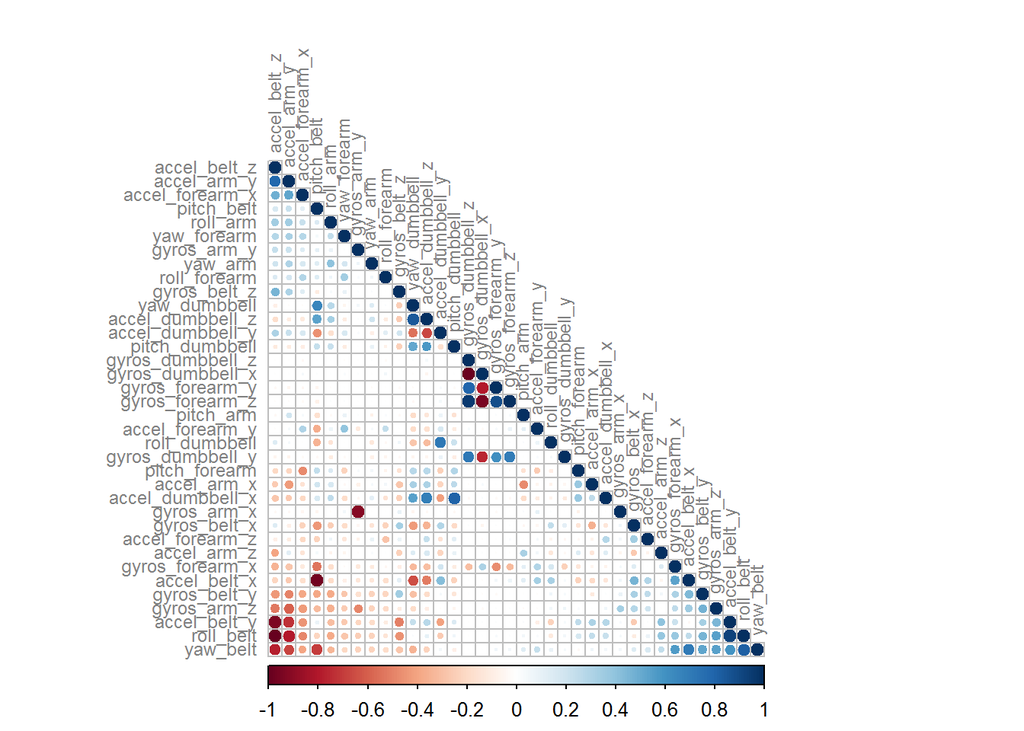

```r
corMat <- cor(training.set[, -37])
corrplot(corMat, method = "circle", type = "lower", order = "FPC", tl.cex = 0.75, tl.col = gray(.5))
```

Most features do not show strong correlations. The decision is to keep them all for now.

At this point I run two models - GBM and Random Forest - not for true modeling, but only to check for variabbles importance according to these models.

```r
if( ! model.saved ) {
  fit.control <- trainControl(method='cv',
                              number=5,
                              returnResamp='none',
                              verboseIter = FALSE)

  gbm.ex.model <- train(classe~.,
                        data=training.set,
                        trControl=fit.control,
                        method="gbm",
                        verbose = FALSE)

  rf.ex.model <- train(classe~.,
                       data=training.set,
                       trControl=fit.control,
                       method="rf",
                       verbose = FALSE)

  # save the models to RDS
  saveRDS(gbm.ex.model, "gbm_ex_model.rds")
  saveRDS(rf.ex.model, "rf_ex_model.rds")
} else {
  # load the models from RDS
  gbm.ex.model <- readRDS("gbm_ex_model.rds") # to load it
  rf.ex.model <- readRDS("rf_ex_model.rds") # to load it
}
```

Plot the variable importance results.

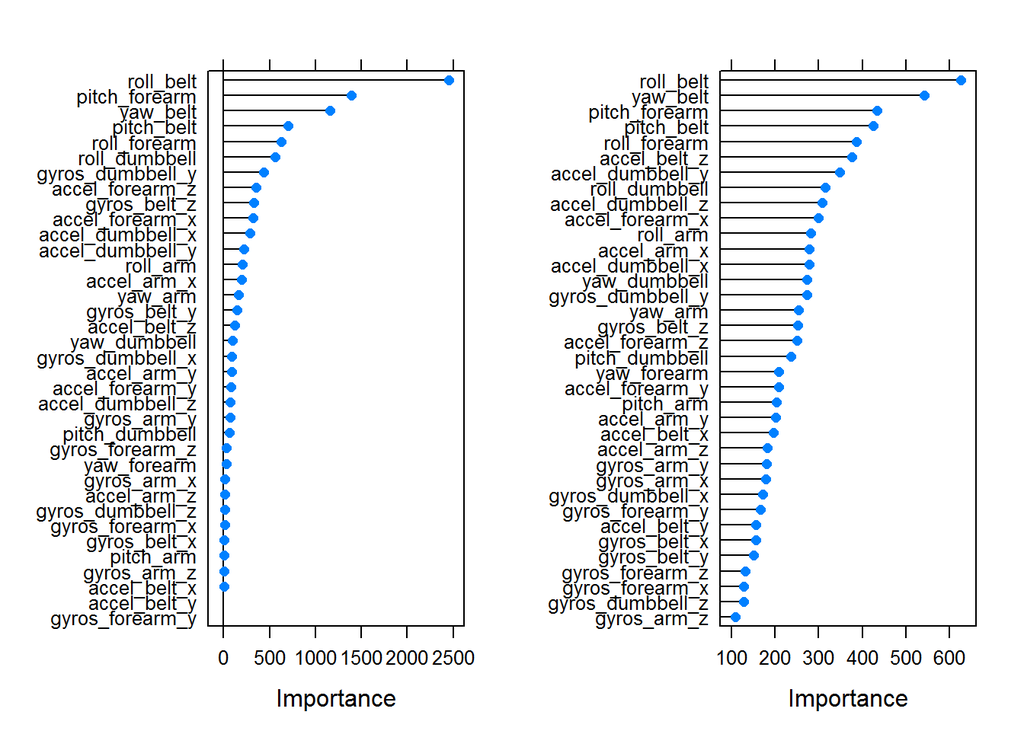

```r
# Plot varImp
g1 = plot(varImp(gbm.ex.model,scale=F, tl.cex = 0.8))
g2 = plot(varImp(rf.ex.model,scale=F, tl.cex = 0.8))
grid.arrange(g1, g2, ncol=2)
```

GBM shows several almost unimportant features. The RF method shows all variables as more or less important. For now I am keeping all variables.

### Modeling

Using the `caret` library, I will build and compare three models of different kinds - GBM, Random Forest, and SVM.

The following train control will be used for all models. It specifies 7-fold cross-validation.

```r
fit.control <- trainControl(method='cv',
                            number=7,
                            returnResamp='none',
                            verboseIter = FALSE)
```

#### GBM Model

```r
if( ! model.saved ) {
  gbm.grid <-  expand.grid(interaction.depth = c(4, 6, 8),
                           n.trees = (15:25)*20,
                           shrinkage = 0.1,
                           n.minobsinnode = c(10,20))
  set.seed(123)
  gbm.model <- train(classe ~ .,
                     data = training.set,
                     method = "gbm",
                     trControl = fit.control,
                     verbose = FALSE,
                     tuneGrid = gbm.grid)
  saveRDS(gbm.model, "gbm_model.rds")
} else {
  gbm.model <- readRDS("gbm_model.rds")
}
```

```r
gbm.model$bestTune
```

```
##    n.trees interaction.depth shrinkage n.minobsinnode
## 66     500                 8       0.1             20
```

```r
gbm.model$finalModel
```

```
## A gradient boosted model with multinomial loss function.
## 500 iterations were performed.
## There were 36 predictors of which 36 had non-zero influence.
```

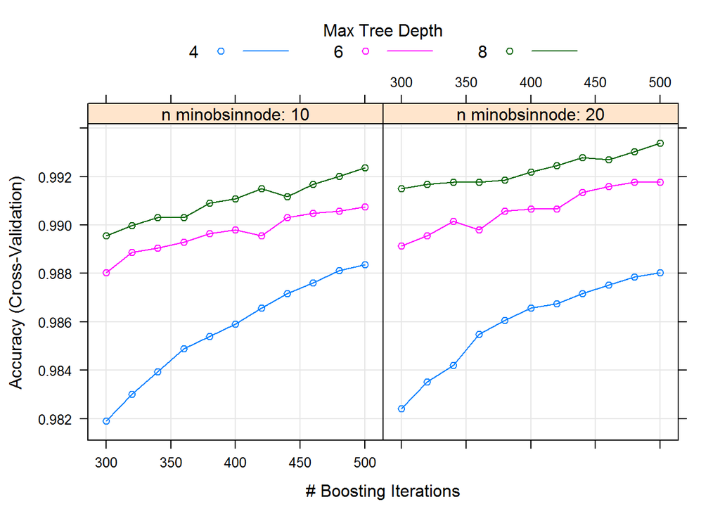

```r
plot(gbm.model)
```

#### Random Forest Model

```r
if( ! model.saved ) {
  set.seed(123)
  rf.model <- train(classe ~ .,
                    data = training.set,
                    method = "rf",
                    trControl = fit.control,
                    verbose = FALSE
  )
  saveRDS(rf.model, "rf_model.rds")
} else {
  rf.model <- readRDS("rf_model.rds")
}
```

```r
rf.model$finalModel
```

```
##
## Call:
##  randomForest(x = x, y = y, mtry = param$mtry, verbose = FALSE)
##                Type of random forest: classification
##                      Number of trees: 500
## No. of variables tried at each split: 2
##
##         OOB estimate of  error rate: 0.92%
## Confusion matrix:
##      A    B    C    D    E class.error
## A 3338    4    3    1    2 0.002986858
## B   17 2256    6    0    0 0.010092146
## C    1   23 2019   11    0 0.017039922
## D    2    0   30 1896    2 0.017616580
## E    0    0    3    3 2159 0.002771363
```

#### SVM Model

```r
if( ! model.saved ) {
  set.seed(123)
  svm.model <- train(classe ~ .,
                    data = training.set,
                    method = "svmRadial",
                    trControl = fit.control,
                    verbose = FALSE
  )
  saveRDS(svm.model, "svm_model.rds")
} else {
  svm.model <- readRDS("svm_model.rds")
}
```

```r
svm.model$finalModel
```

```
## Support Vector Machine object of class "ksvm"
##
## SV type: C-svc  (classification)
##  parameter : cost C = 1
##
## Gaussian Radial Basis kernel function.
##  Hyperparameter : sigma =  0.0217045563722549
##
## Number of Support Vectors : 6863
##
## Objective Function Value : -1231.716 -1120.89 -868.6123 -579.7933 -1081.641 -626.1985 -909.2903 -1009.198 -744.4442 -647.6884
## Training error : 0.090693
```

### Evaluate and compare the models using the *validation* set

```r
gbm.val.pred <- predict(gbm.model, newdata = validation.set)
gbm.val.cm <- confusionMatrix(gbm.val.pred, validation.set$classe)

rf.val.pred <- predict(rf.model, newdata = validation.set)
rf.val.cm <- confusionMatrix(rf.val.pred, validation.set$classe)

svm.val.pred <- predict(svm.model, newdata = validation.set)
svm.val.cm <- confusionMatrix(svm.val.pred, validation.set$classe)
```

The following code can be used to print and review the full confusion matrices.

```r
gbm.val.cm; rf.val.cm; svm.val.cm
```

Here I am comparing the accuracy and kappa values for the three modules.

```r
gbm.accuracy <- gbm.val.cm$overall[[1]]
gbm.kappa <- gbm.val.cm$overall[[2]]

rf.accuracy <- rf.val.cm$overall[[1]]
rf.kappa <- rf.val.cm$overall[[2]]

svm.accuracy <- svm.val.cm$overall[[1]]
svm.kappa <- svm.val.cm$overall[[2]]

tb <- data.frame(c(gbm.accuracy, rf.accuracy, svm.accuracy),
                 c(gbm.kappa, rf.kappa, svm.kappa),
                 row.names = c("GBM", "Random Forest", "SVM"))
names(tb) <- c("accuracy", "cappa")

tb
```

```
##                accuracy     cappa
## GBM           0.9941371 0.9925837
## Random Forest 0.9898037 0.9871016
## SVM           0.9003314 0.8736648
```

In this case the GBM model showed best performance on the validation set. I am selecting GBM as final model to be used on this project for this specific data set.

### Evaluate the out of sample performance for the final model

The following code runs the previously created and selected GBM model on the *testing set*. Now for the first time I am using my *testing set*.

```r
gbm.tst.pred <- predict(gbm.model, newdata = testing.set)
gbm.tst.cm <- confusionMatrix(gbm.tst.pred, testing.set$classe  )
gbm.tst.cm
```

```
## Confusion Matrix and Statistics
##
##           Reference
## Prediction    A    B    C    D    E
##          A 1112    0    0    0    0
##          B    0  759    6    0    0
##          C    1    0  672    2    2
##          D    3    0    6  639    1
##          E    0    0    0    2  718
##
## Overall Statistics
##
##                Accuracy : 0.9941
##                  95% CI : (0.9912, 0.9963)
##     No Information Rate : 0.2845
##     P-Value [Acc > NIR] : < 2.2e-16
##
##                   Kappa : 0.9926
##  Mcnemar's Test P-Value : NA
##
## Statistics by Class:
##
##                      Class: A Class: B Class: C Class: D Class: E
## Sensitivity            0.9964   1.0000   0.9825   0.9938   0.9958
## Specificity            1.0000   0.9981   0.9985   0.9970   0.9994
## Pos Pred Value         1.0000   0.9922   0.9926   0.9846   0.9972
## Neg Pred Value         0.9986   1.0000   0.9963   0.9988   0.9991
## Prevalence             0.2845   0.1935   0.1744   0.1639   0.1838
## Detection Rate         0.2835   0.1935   0.1713   0.1629   0.1830
## Detection Prevalence   0.2835   0.1950   0.1726   0.1654   0.1835
## Balanced Accuracy      0.9982   0.9991   0.9905   0.9954   0.9976
```

The result shows out of sample accuracy `0.9941` and kappa `0.9926`. The confidence interval and p-value are also quite reasonably good: `(0.9912, 0.9963)` and `< 2.2e-16` correspondingly.

### Prepare and submit the prediction on the given 20-sample test

Now I will use the same GBM model to perform prediction on the *given test set* of 20 samples, which has not been used until now.

The code below is used to read the 20-sample dataset, select the features used on the training set, and then predict the outcome using the previously built GBM model. Note that the 20-sample test does not have outcome variable. It will be predicted and submitted to Coursera for grading.

```r
given.test.set = read.csv("data-project/pml-testing.csv")
given.test.set = given.test.set[,predictorNames]
gbm.to.submit.pred <- predict(gbm.model, newdata = given.test.set)
```

Split the result in 20 separate files and upload them as required.

```r
pml_write_files = function(x) {
  n = length(x)
  for(i in 1:n){
    filename = paste0("problem_id_",i,".txt")
    write.table(x[i],file=filename,quote=FALSE,row.names=FALSE,col.names=FALSE)
  }
}

pml_write_files(as.character(gbm.to.submit.pred))
```